# Final project

Alfonso D’Amelio

20/6/2018

# Orange tree growth: a nonlinear mixed-effects models

## Introduction

In this document i’ll led a fully bayesian analysis dealing with the growth of the circumference of a population of orange trees.

The main topics will be covered are:

- Simple statistics and differences between the growth of different types of trees.
- Apply three different nonlinear mixed-effects statistical models and evaluate the estimation performance of models implemented.
- Evaluate the best statistical model according to the **DIC** (*Deviance Information Criterion*).
- Once reconstruct the tree’s profile and chosen the best model, evaluate the chains obtained by **JAGS** simulations and visualize the approximated marginal posteriors.

## Data Description

The orange tree growth data, originally taken from Draper & Smith (1981) and reproduced in Draper & Smith (1998), was used by Pinheiro & Bates (2000) to illustrate how a *logistic* growth curve model with random effects can be implemented with the **S-Plus** function nlme.

The data contain measurements of trunk circumferences (mm) made at seven occasions for each of five orange trees, over roughly a four year period of growth shown in the Figure 1.

During this study could be interesting analyze and describe the average growth pattern in the population,for example how the mean of the circumference in the orange trees population changes over time.

It may also be interesting how the growth of individual trees vary across the population.

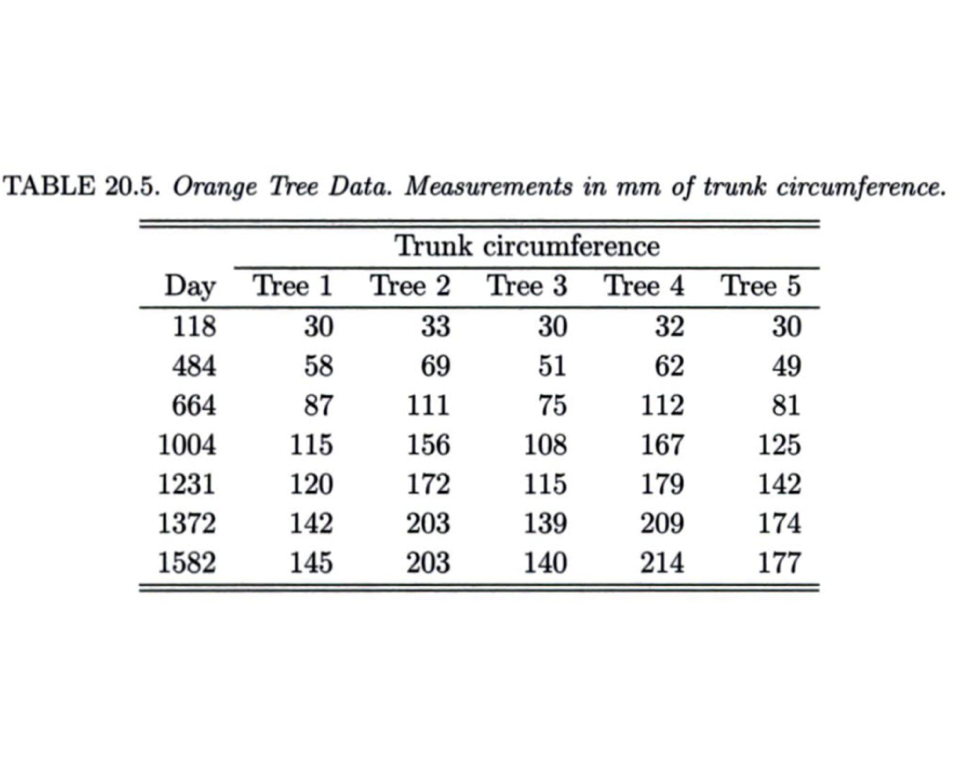

Orange tree growth data are an example of *longitudinal data*, sometimes called panel data,a collection of repeated observations of the same subjects (trunk circumferences), taken from a larger population (trees), over a period of time – and is useful for measuring change.

Longitudinal data differs from cross-sectional data because it follows the same subjects over a period of time, while cross-sectional data samples different subjects (whether individuals, firms, countries or regions) at each point in time.

At this point we are able to make a simple visualization of the growth for each of the five trees; underlying the flattish “S” shape before explained and the increasing of the difference (growth) between trees population according to the age.

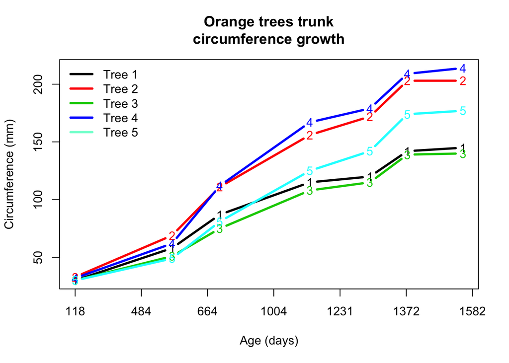

```r
data <- list(n = 7, K = 5,
              x = c(118.00, 484.00, 664.00, 1004.00, 1231.00, 1372.00, 1582.00),
              Y = matrix( c(30.00, 58.00, 87.00, 115.00, 120.00, 142.00, 145.00,
                          33.00, 69.00, 111.00, 156.00, 172.00, 203.00, 203.00,
                          30.00, 51.00, 75.00, 108.00, 115.00, 139.00, 140.00,
                          32.00, 62.00, 112.00, 167.00, 179.00, 209.00, 214.00,
                          30.00, 49.00, 81.00, 125.00, 142.00, 174.00, 177.00),
                          nrow = 5, ncol = 7, byrow = TRUE))
n = 7
K = 5
ages <- data$x
matplot(ages, t(data$Y), type = "b", lwd = 3,
        xlab = "Age (days)", ylab = "Circumference (mm)",lty = 1,xaxt='n')
axis(1, at= seq(118,1800,250),labels = c(118, 484, 664, 1004, 1231, 1372, 1582))
legend('topleft',legend = c('Tree 1','Tree 2','Tree 3','Tree 4','Tree 5'),col=c('black','red','green3','blue','aquamarine'),lwd=3,bty = "n")
title(main= "Orange trees trunk\ncircumference growth")
```

## Intro to NLME (Non-linear Mixed Effects Model)

As far as we said before, in this model mixed effects occur non-linearly in the response variable $y$. The general formula of the NLME suggested by Lindstrom and Bates (1990) is:

$${y} = {f}(\boldsymbol{\phi,X}) + \boldsymbol{\epsilon}, \quad \text{where} \quad \boldsymbol{\phi} = \boldsymbol{A\beta + Bb}$$

where $y$ is the response vector, $f$ is a general non-linear function, $\boldsymbol{\phi}$ is a mixed effects parameter vector that is expressed as a linear combination of *fixed effects* $\boldsymbol{\beta}$ and *random effects* $b$, $X$ is the matrix of covariates, $\boldsymbol{\epsilon}$ is the error vector, $A,B$ are the design matrices for fixed and random effects respectively.

Moreover $b \sim N(0,D)$, $\boldsymbol{\epsilon} \sim N(0,\boldsymbol{\Lambda})$, with $\boldsymbol{\epsilon}$ and $b$ independent.

## Model

### Description

Pinheiro and Bates (2000) used the following mixed-effects logistic model to analyze the orange tree growth data:

$$y_{ij} = \frac{\phi_{i1}}{1 + exp\bigg(−\frac{(x_{ij} −\phi_{i2})}{\phi_{i3}}\bigg)}+\epsilon_{ij}, \quad \epsilon_{ij}\sim N(0,\sigma^2)$$

where:

- $y_{ij}$ is the circumference of tree $i$ at time $j$, $x$ is the age in days.
- $\phi_{i1}$: linear combination of the first fixed effect $\beta_1$ and eventually a random effect $b_{i1}$.
- $\phi_{i2}$: linear combination of the first fixed effect $\beta_2$ and eventually a random effect $b_{i2}$.
- $\phi_{i3}$: linear combination of the first fixed effect $\beta_3$ and eventually a random effect $b_{i3}$.

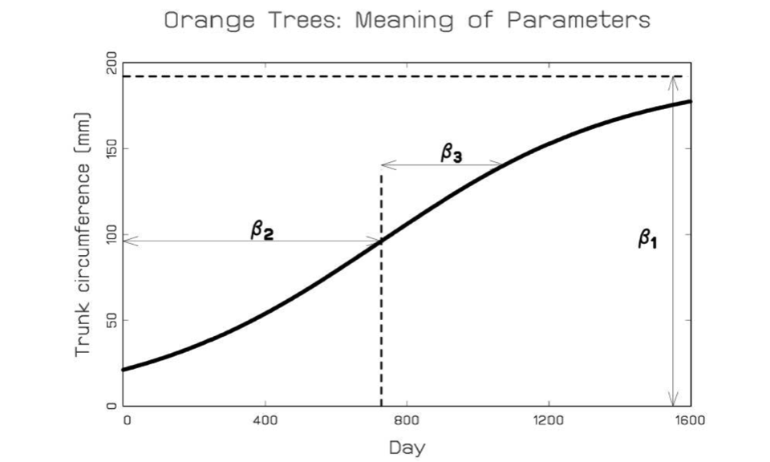

In the figure above is reported the profile of the logistic function with its 3 fixed effects paramaters which describe:  
- $\beta_1$: is the asympotic circumference  
- $\beta_2$: is the time at which half of the asymptotic value is reached  
- $\beta_3$: is the measure for the curvature at $\beta_2$

Lindstrom and Bates (1990) concluded in their analysis (which is the first model implemented) that only the asymptotic circumference needed a random effect to account the tree-to-tree variation, so only $\phi_{i1}$ can be expressed as a linear combination of fixed and random effects. Anyway, in this study we will try to check/demonstrate the presence of other random effects on $\beta_2$ and $\beta_3$, adopting similar models.

### DAG

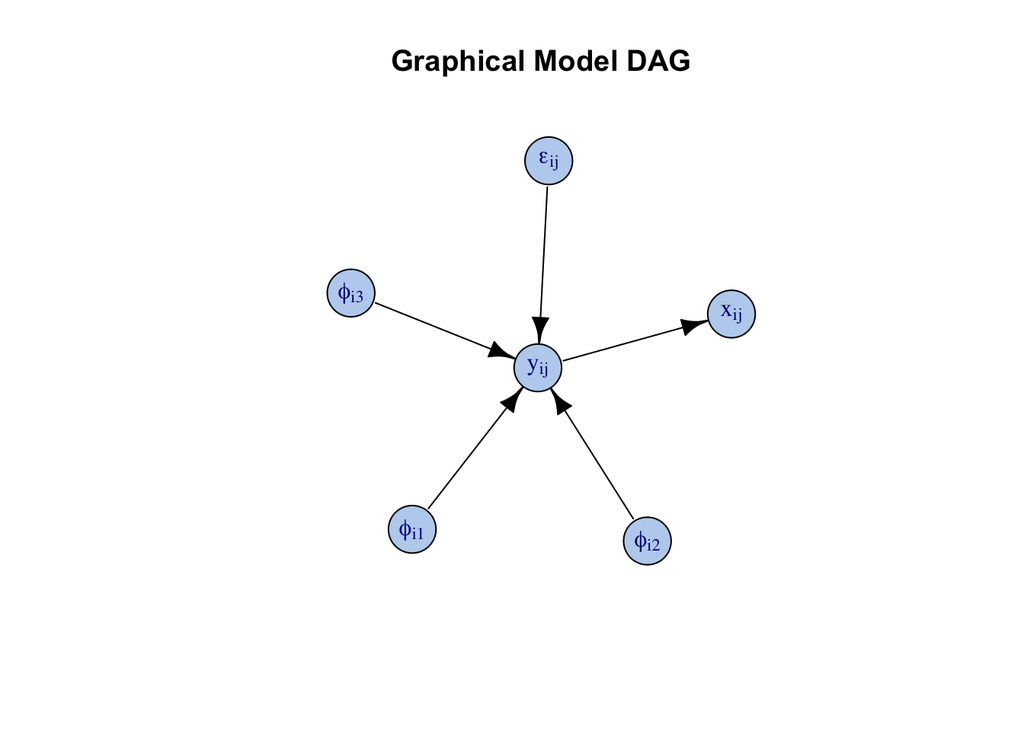

```r
require(igraph)
graph <- make_empty_graph(directed=T)
graph <- graph + vertex(name=expression(x[ij])) + vertex(name=expression(y[ij])) + vertex(name=expression(phi[i1])) + vertex(name=expression(epsilon[ij])) + vertex(name=expression(phi[i3])) + vertex(name=expression(phi[i2]))
graph <- graph + edge(2, 1)+ edge(3, 2)+ edge(4, 2) + edge(5, 2) + edge(6, 2)
l <- layout_with_fr(graph)
set.seed(13)
plot(graph,vertex.size=25,edge.arrow.size=0.9,edge.color='black',main="Graphical Model DAG",vertex.color="lightsteelblue2",layout=l)
```

# Model implemented in JAGS

- **First model with random effect only in $\phi_{i1}$**

$$\text{Model 1: } \quad \begin{matrix}
{A}_{i} = {I}\\
{B}_{i} = (1,0,0)^{T}\\
\boldsymbol{\beta} = (\beta_1, \beta_2, \beta_3)
\end{matrix} \quad \left\{\begin{matrix}
\phi_{i1} = \beta_1 + b_{i1}\\
\phi_{i2} = \beta_2\\
\phi_{i3} = \beta_3\\
\phi_{i1} \sim N(\mu_1,\tau_1)\\
\phi_{i2} = \phi_2 \sim N(0,\tau = 0.0001)\\
\phi_{i3} = \phi_3 \sim N(0,\tau = 0.0001)\\
\mu_{1} \sim N(0,0.0001)\\
\tau_{1} \sim \Gamma(0.001,0.001)\\
\tau_C \sim \Gamma(0.001,0.001)
\end{matrix}\right.$$

- **Second model with random effect both in $\phi_{i1}$ and $\phi_{i2}$**

$$\text{Model 2: } \quad \begin{matrix}
{A}_{i} = {I}\\
{B}_{i} = (1,1,0)^{T}\\
\boldsymbol{\beta} = (\beta_1, \beta_2, \beta_3)
\end{matrix} \quad \left\{\begin{matrix}
\phi_{i1} = \beta_1 + b_{i1}\\
\phi_{i2} = \beta_2 + b_{i2}\\
\phi_{i3} = \beta_3\\
\phi_{i1} \sim N(\mu_1,\tau_1)\\
\phi_{i2} \sim N(\mu_2,\tau_2)\\
\phi_{i3} = \phi_3 \sim N(0,\tau = 0.0001)\\
\mu_{1} \sim N(0,0.0001)\\
\mu_{2} \sim N(0,0.0001)\\
\tau_{1} \sim \Gamma(0.001,0.001)\\
\tau_{2} \sim \Gamma(0.001,0.001)\\
\tau_C \sim \Gamma(0.001,0.001)
\end{matrix}\right.$$

- **Third model with random effect in $\phi_{i1}$, $\phi_{i2}$ and also in $\phi_{i3}$**

$$\text{Model 3: } \quad \begin{matrix}
{A}_{i} = {I}\\
{B}_{i} = (1,1,1)^{T}\\
\boldsymbol{\beta} = (\beta_1, \beta_2, \beta_3)
\end{matrix} \quad \left\{\begin{matrix}
\phi_{i1} = \beta_1 + b_{i1}\\
\phi_{i2} = \beta_2 + b_{i2}\\
\phi_{i3} = \beta_3 + b_{i3}\\
\phi_{i1} \sim N(\mu_1,\tau_1)\\
\phi_{i2} \sim N(\mu_2,\tau_2)\\
\phi_{i3} \sim N(\mu_3,\tau_3)\\
\mu_{1} \sim N(0,0.0001)\\
\mu_{2} \sim N(0,0.0001)\\
\mu_{3} \sim N(0,0.0001)\\
\tau_{1} \sim \Gamma(0.001,0.001)\\
\tau_{2} \sim \Gamma(0.001,0.001)\\
\tau_{3} \sim \Gamma(0.001,0.001)\\
\tau_C \sim \Gamma(0.001,0.001)
\end{matrix}\right.$$

For each of these 3 models we will evaluate their ability of recover their parameters and we will evaluate the **DIC** in order to identify the *best* model that can deal with these data.

## What is the **DIC**?

The deviance information criterion (DIC) is a hierarchical modeling generalization of the Akaike information criterion (AIC) and the Bayesian information criterion (BIC). It is particularly useful in Bayesian model selection problems where the posterior distributions of the models have been obtained by Markov chain Monte Carlo (MCMC) simulation (our case).

We define the:

1- *Deviance* as $D(\theta )=-2\log(p(y|\theta))+C,$

2- then we have $p_{D}={\bar {D}}-D({\bar {\theta }})$ which is the *effective number of parameters of the model*.

So:
$${\mathit {DIC}}=D({\bar {\theta }})+2p_{D}$$
The general idea is that models with smaller DIC should be preferred to models with larger DIC.

### Model 1

The corresponding JAGS code is the following:

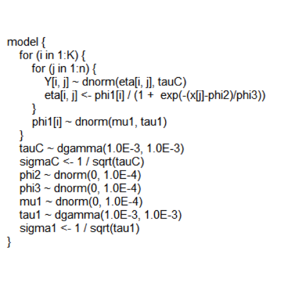

```r
parameters = c("mu1","tau1","sigma1","tauC","sigmaC","phi1","phi2","phi3")
inits = list(phi1=rep(0,data$K),phi2 =0, phi3=1, mu1=0, tau1=0.1, tauC=1)
initial.values = list(inits)

orange1 = jags( data = data,  inits = initial.values,
               parameters.to.save = parameters,
               model.file = "orange_trees_model_v2.txt",
               n.chain = 1,
               n.iter = 10000,
               n.burnin = 1000,
               n.thin = 1,
               working.directory = "/Users/alfonsodamelio/Desktop/FinalProject",
               DIC = TRUE)
```

```
## module glm loaded
```

```r
print(orange1)
```

```
## Inference for Bugs model at "orange_trees_model_v2.txt", fit using jags,
##  1 chains, each with 10000 iterations (first 1000 discarded)
##  n.sims = 9000 iterations saved
##          mu.vect sd.vect    2.5%     25%     50%     75%   97.5%
## mu1      171.330  20.918 125.223 160.780 172.608 183.707 208.955
## phi1[1]  150.526   6.431 137.272 146.425 150.725 154.762 162.779
## phi1[2]  206.923   7.762 190.738 202.029 207.187 212.110 221.496
## phi1[3]  143.439   6.372 130.322 139.296 143.676 147.697 155.680
## phi1[4]  214.610   7.920 198.156 209.524 214.864 219.943 229.442
## phi1[5]  172.549   6.960 158.351 168.036 172.776 177.179 186.193
## phi2     642.359  32.119 574.862 621.674 644.478 664.112 701.228
## phi3     293.243  24.898 241.975 277.463 293.742 310.067 340.457
## sigma1    40.897  20.453  18.868  27.943  35.700  47.526  95.167
## sigmaC     9.505   1.638   6.992   8.332   9.295  10.413  13.394
## tau1       0.001   0.001   0.000   0.000   0.001   0.001   0.003
## tauC       0.012   0.004   0.006   0.009   0.012   0.014   0.020
## deviance 255.877   8.001 243.931 249.960 254.714 260.566 274.536
##
## DIC info (using the rule, pD = var(deviance)/2)
## pD = 32.0 and DIC = 287.9
## DIC is an estimate of expected predictive error (lower deviance is better).
```

### Model 2

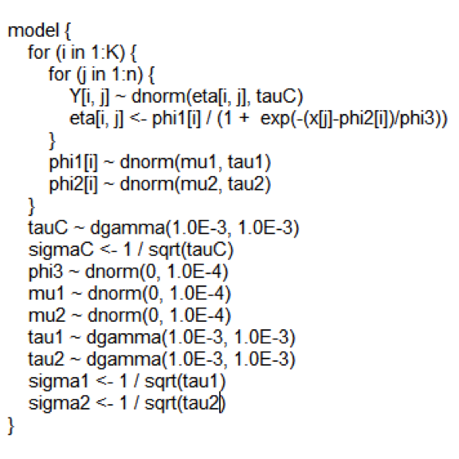

```r
parameters = c("mu1","tau1","mu2","tau2","sigma1","sigma2","tauC","sigmaC","phi1","phi2","phi3")
inits = list(phi1=rep(0,data$K), phi2 =rep(0,data$K),
             phi3=1, mu1=0, mu2=0, tau1=0.1, tau2=0.1, tauC=1)
initial.values = list(inits)

orange2 = jags( data = data,  inits = initial.values,
                parameters.to.save = parameters,
                model.file = "orange_trees_model_v3.txt",
                n.chain = 1,
                n.iter = 10000,
                n.burnin = 1000,
                n.thin = 1,
                working.directory = "/Users/alfonsodamelio/Desktop/FinalProject",
                DIC = TRUE)
print(orange2)
```

```
## Inference for Bugs model at "orange_trees_model_v3.txt", fit using jags,
##  1 chains, each with 10000 iterations (first 1000 discarded)
##  n.sims = 9000 iterations saved
##          mu.vect sd.vect     2.5%     25%     50%     75%    97.5%
## mu1      176.794  27.638  112.656 164.614 179.586 192.677  221.980
## mu2       86.837 109.305 -124.983  13.072  84.652 159.474  307.139
## phi1[1]  150.196   7.292  136.782 145.307 149.874 154.602  165.957
## phi1[2]  216.766   8.938  200.009 210.671 216.570 222.611  235.104
## phi1[3]  147.756   7.779  133.555 142.472 147.372 152.741  164.493
## phi1[4]  230.074   9.754  211.940 223.568 229.729 236.137  250.794
## phi1[5]  192.605  10.340  173.953 185.609 191.933 198.924  214.749
## phi2[1]  603.832  62.677  484.960 561.990 602.276 644.449  732.703
## phi2[2]  689.454  48.300  595.765 657.058 689.611 721.286  785.631
## phi2[3]  666.559  66.028  538.691 622.065 665.894 709.783  801.662
## phi2[4]  726.075  47.485  631.614 696.016 725.570 756.342  822.251
## phi2[5]  791.826  58.682  676.671 753.113 791.140 829.211  910.350
## phi3     327.191  25.340  278.601 309.711 326.320 344.142  378.094
## sigma1    50.255  29.873   22.333  32.857  42.555  58.080  124.777
## sigma2   729.907 351.400  317.714 512.003 656.595 856.875 1573.221
## sigmaC     7.946   1.224    5.992   7.082   7.791   8.644   10.778
## tau1       0.001   0.001    0.000   0.000   0.001   0.001    0.002
## tau2       0.000   0.000    0.000   0.000   0.000   0.000    0.000
## tauC       0.017   0.005    0.009   0.013   0.016   0.020    0.028
## deviance 243.476   6.409  233.675 238.768 242.560 247.340  257.895
##
## DIC info (using the rule, pD = var(deviance)/2)
## pD = 20.5 and DIC = 264.0
## DIC is an estimate of expected predictive error (lower deviance is better).
```

### Model 3

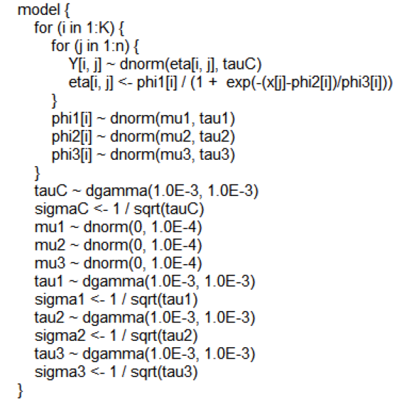

```r
parameters = c("mu1","tau1","mu2","tau2","mu3","tau3",
               "sigma1","sigma2","sigma3","tauC","sigmaC","phi1","phi2","phi3")
inits = list(phi1=rep(0,data$K), phi2 =rep(0,data$K),
             phi3=rep(1,data$K), mu1=0, mu2=0, mu3=0,
             tau1=0.1, tau2=0.1, tau3=0.1, tauC=1)
initial.values = list(inits)

orange3 = jags( data = data,  inits = initial.values,
                parameters.to.save = parameters,
                model.file = "orange_trees_model_v4.txt",
                n.chain = 1,
                n.iter = 10000,
                n.burnin = 1000,
                n.thin = 1,
                working.directory = "/Users/alfonsodamelio/Desktop/FinalProject",
                DIC = TRUE)
print(orange3)
```

```
## Inference for Bugs model at "orange_trees_model_v4.txt", fit using jags,
##  1 chains, each with 10000 iterations (first 1000 discarded)
##  n.sims = 9000 iterations saved
##          mu.vect sd.vect     2.5%     25%     50%     75%    97.5%
## mu1      166.348  28.209  113.135 148.951 168.647 185.181  214.477
## mu2      117.898 107.694 -102.630  51.587 126.234 183.990  352.895
## mu3      253.542 116.910  -45.435 238.858 301.943 327.817  363.227
## phi1[1]  146.416  14.090  115.610 139.924 147.150 153.374  176.431
## phi1[2]  194.684  29.901  128.439 170.278 207.701 216.971  230.517
## phi1[3]  144.488  15.391  111.245 136.408 145.088 152.817  176.278
## phi1[4]  204.033  35.249  128.420 172.284 219.654 230.279  246.895
## phi1[5]  177.979  26.081  121.967 160.606 185.238 195.141  221.692
## phi2[1]  445.243 193.951  112.581 218.780 539.532 598.525  674.937
## phi2[2]  504.740 239.175   96.006 215.193 638.168 692.649  756.843
## phi2[3]  480.202 236.189   54.827 215.882 601.491 669.937  769.283
## phi2[4]  530.032 266.084   56.518 213.879 680.340 732.755  815.811
## phi2[5]  583.607 300.724   62.538 215.886 746.372 806.856  948.251
## phi3[1]  406.854 370.688   24.441 290.402 322.703 350.558 1657.620
## phi3[2]  320.653 141.258   24.340 285.433 317.385 339.131  679.676
## phi3[3]  497.106 777.331   24.291 292.727 324.994 357.667 2120.647
## phi3[4]  308.765 108.847   24.400 282.879 314.268 335.267  581.636
## phi3[5]  368.430 247.731   24.190 291.967 324.495 352.614 1100.086
## sigma1    37.580  31.141    0.641  19.343  34.262  49.238  110.861
## sigma2   477.300 421.628    0.414  44.604 488.531 721.236 1397.850
## sigma3   195.053 572.966    0.342   1.769   8.163  47.188 1799.359
## sigmaC    18.121  14.456    6.112   7.494   8.927  32.781   48.360
## tau1       0.239   1.556    0.000   0.000   0.001   0.003    2.436
## tau2       0.449   2.224    0.000   0.000   0.000   0.001    5.822
## tau3       0.864   2.870    0.000   0.000   0.015   0.319    8.572
## tauC       0.011   0.009    0.000   0.001   0.013   0.018    0.027
## deviance 281.540  51.297  233.643 240.822 248.992 346.879  367.268
##
## DIC info (using the rule, pD = var(deviance)/2)
## pD = 1315.7 and DIC = 1597.2
## DIC is an estimate of expected predictive error (lower deviance is better).
```

At this point i save the output of jags (chain) for each parameter in arrays, building up a structure that allow me to reconstruct than the profile of each tree according to the three different model used.

```r
# MODEL 1
mu1 = mcmc(orange1$BUGSoutput$sims.array[,1,c("mu1")])
sigma1 = mcmc(orange1$BUGSoutput$sims.array[,1,c("sigma1")])
sigmaC = mcmc(orange1$BUGSoutput$sims.array[,1,c("sigmaC")])

phi1 = list()
phi1$i1 = mcmc(orange1$BUGSoutput$sims.array[,1,c("phi1[1]")])
phi1$i2 = mcmc(orange1$BUGSoutput$sims.array[,1,c("phi1[2]")])
phi1$i3 = mcmc(orange1$BUGSoutput$sims.array[,1,c("phi1[3]")])
phi1$i4 = mcmc(orange1$BUGSoutput$sims.array[,1,c("phi1[4]")])
phi1$i5 = mcmc(orange1$BUGSoutput$sims.array[,1,c("phi1[5]")])

phi2 = mcmc(orange1$BUGSoutput$sims.array[,1,c("phi2")])
phi3 = mcmc(orange1$BUGSoutput$sims.array[,1,c("phi3")])

f1 = matrix(ncol = 7, nrow = 5)
for(i in 1:7){
  f1[1,i] = mean(phi1$i1/(1+exp(-(ages[i]-phi2)/phi3)))
  f1[2,i] = mean(phi1$i2/(1+exp(-(ages[i]-phi2)/phi3)))
  f1[3,i] = mean(phi1$i3/(1+exp(-(ages[i]-phi2)/phi3)))
  f1[4,i] = mean(phi1$i4/(1+exp(-(ages[i]-phi2)/phi3)))
  f1[5,i] = mean(phi1$i5/(1+exp(-(ages[i]-phi2)/phi3)))
}

# MODEL 2
mu1 = mcmc(orange2$BUGSoutput$sims.array[,1,c("mu1")])
mu2 = mcmc(orange2$BUGSoutput$sims.array[,1,c("mu2")])

sigma1 = mcmc(orange2$BUGSoutput$sims.array[,1,c("sigma1")])
sigma2 = mcmc(orange2$BUGSoutput$sims.array[,1,c("sigma2")])
sigmaC = mcmc(orange2$BUGSoutput$sims.array[,1,c("sigmaC")])

phi1 = list()
phi1$i1 = mcmc(orange2$BUGSoutput$sims.array[,1,c("phi1[1]")])
phi1$i2 = mcmc(orange2$BUGSoutput$sims.array[,1,c("phi1[2]")])
phi1$i3 = mcmc(orange2$BUGSoutput$sims.array[,1,c("phi1[3]")])
phi1$i4 = mcmc(orange2$BUGSoutput$sims.array[,1,c("phi1[4]")])
phi1$i5 = mcmc(orange2$BUGSoutput$sims.array[,1,c("phi1[5]")])

phi2 = list()
phi2$i1 = mcmc(orange2$BUGSoutput$sims.array[,1,c("phi2[1]")])
phi2$i2 = mcmc(orange2$BUGSoutput$sims.array[,1,c("phi2[2]")])
phi2$i3 = mcmc(orange2$BUGSoutput$sims.array[,1,c("phi2[3]")])
phi2$i4 = mcmc(orange2$BUGSoutput$sims.array[,1,c("phi2[4]")])
phi2$i5 = mcmc(orange2$BUGSoutput$sims.array[,1,c("phi2[5]")])
phi3 = mcmc(orange2$BUGSoutput$sims.array[,1,c("phi3")])

f2 = matrix(ncol = 7, nrow = 5)
for(i in 1:7){
  f2[1,i] = mean(phi1$i1/(1+exp(-(ages[i]-phi2$i1)/phi3)))
  f2[2,i] = mean(phi1$i2/(1+exp(-(ages[i]-phi2$i2)/phi3)))
  f2[3,i] = mean(phi1$i3/(1+exp(-(ages[i]-phi2$i3)/phi3)))
  f2[4,i] = mean(phi1$i4/(1+exp(-(ages[i]-phi2$i4)/phi3)))
  f2[5,i] = mean(phi1$i5/(1+exp(-(ages[i]-phi2$i5)/phi3)))
}


# MODEL 3
mu1 = mcmc(orange3$BUGSoutput$sims.array[,1,c("mu1")])
mu2 = mcmc(orange3$BUGSoutput$sims.array[,1,c("mu2")])
mu3 = mcmc(orange3$BUGSoutput$sims.array[,1,c("mu3")])

sigma1 = mcmc(orange3$BUGSoutput$sims.array[,1,c("sigma1")])
sigma2 = mcmc(orange3$BUGSoutput$sims.array[,1,c("sigma2")])
sigma3 = mcmc(orange3$BUGSoutput$sims.array[,1,c("sigma3")])
sigmaC = mcmc(orange3$BUGSoutput$sims.array[,1,c("sigmaC")])

phi1 = list()
phi1$i1 = mcmc(orange3$BUGSoutput$sims.array[,1,c("phi1[1]")])
phi1$i2 = mcmc(orange3$BUGSoutput$sims.array[,1,c("phi1[2]")])
phi1$i3 = mcmc(orange3$BUGSoutput$sims.array[,1,c("phi1[3]")])
phi1$i4 = mcmc(orange3$BUGSoutput$sims.array[,1,c("phi1[4]")])
phi1$i5 = mcmc(orange3$BUGSoutput$sims.array[,1,c("phi1[5]")])

phi2 = list()
phi2$i1 = mcmc(orange3$BUGSoutput$sims.array[,1,c("phi2[1]")])
phi2$i2 = mcmc(orange3$BUGSoutput$sims.array[,1,c("phi2[2]")])
phi2$i3 = mcmc(orange3$BUGSoutput$sims.array[,1,c("phi2[3]")])
phi2$i4 = mcmc(orange3$BUGSoutput$sims.array[,1,c("phi2[4]")])
phi2$i5 = mcmc(orange3$BUGSoutput$sims.array[,1,c("phi2[5]")])

phi3 = list()
phi3$i1 = mcmc(orange3$BUGSoutput$sims.array[,1,c("phi3[1]")])
phi3$i2 = mcmc(orange3$BUGSoutput$sims.array[,1,c("phi3[2]")])
phi3$i3 = mcmc(orange3$BUGSoutput$sims.array[,1,c("phi3[3]")])
phi3$i4 = mcmc(orange3$BUGSoutput$sims.array[,1,c("phi3[4]")])
phi3$i5 = mcmc(orange3$BUGSoutput$sims.array[,1,c("phi3[5]")])

f3 = matrix(ncol = 7, nrow = 5)
for(i in 1:7){
  f3[1,i] = mean(phi1$i1/(1+exp(-(ages[i]-phi2$i1)/phi3$i1)))
  f3[2,i] = mean(phi1$i2/(1+exp(-(ages[i]-phi2$i2)/phi3$i2)))
  f3[3,i] = mean(phi1$i3/(1+exp(-(ages[i]-phi2$i3)/phi3$i3)))
  f3[4,i] = mean(phi1$i4/(1+exp(-(ages[i]-phi2$i4)/phi3$i4)))
  f3[5,i] = mean(phi1$i5/(1+exp(-(ages[i]-phi2$i5)/phi3$i5)))
}
```

## Model selection

We have two ways for determining which is the best model for these data:

1. We can visually inspect the fit of all models: upon reconstructed the profiles of the growth of each tree under each of the 3 models, we can visualize them e check wheter they follow the behaviour of the logistic function
2. We can evaluate the DIC (Deviance Information Criterion): as said before $\rightarrow$the lower the DIC, the better the model.

### Models fits

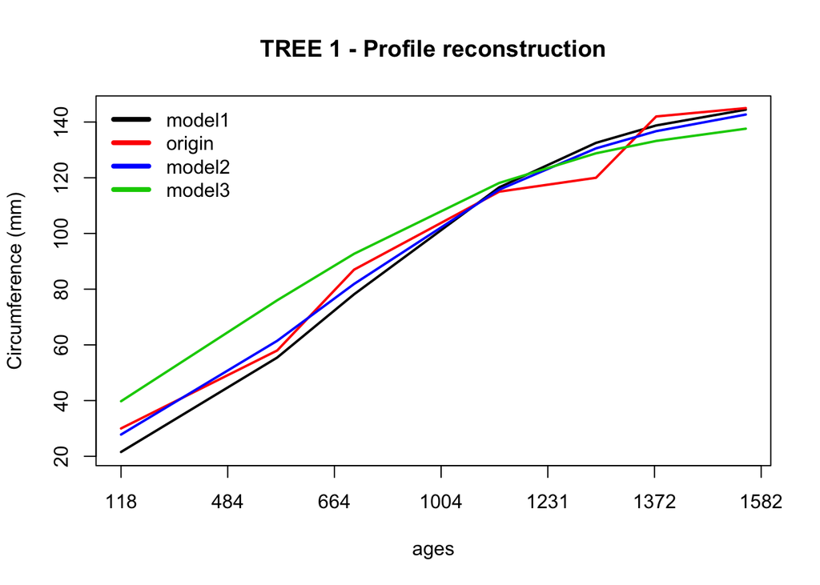

```r
# tree 1
matplot(ages, f1[1,], type = "l", lwd=2, ylab = "Circumference (mm)",xaxt='n')
points(ages, data$Y[1,], type = "l", col="red", lwd=2)
points(ages, f2[1,], type = "l", col="blue", lwd=2)
points(ages, f3[1,], type = "l", col="green3", lwd=2)
title(main="TREE 1 - Profile reconstruction")
legend(x="topleft", bty="n", legend = c("model1","origin","model2","model3"),
       col=c("black","red","blue","green3"), lwd = 4)
axis(1, at= seq(118,1800,250),labels = c(118, 484, 664, 1004, 1231, 1372, 1582))
```

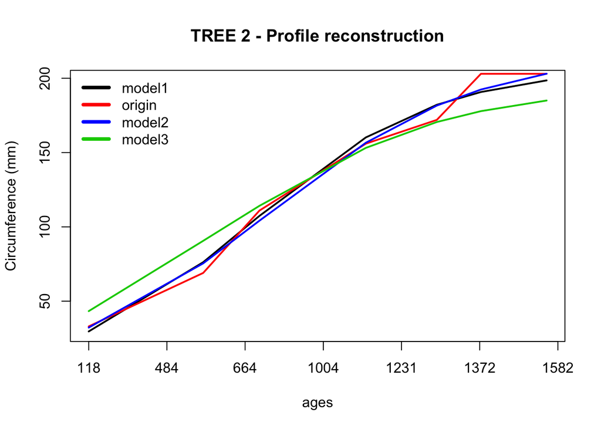

```r
# tree 2
matplot(ages, f1[2,], type = "l", lwd=2, ylab = "Circumference (mm)",xaxt='n')
points(ages, data$Y[2,], type = "l", col="red", lwd=2)
points(ages, f2[2,], type = "l", col="blue", lwd=2)
points(ages, f3[2,], type = "l", col="green3", lwd=2)
title(main="TREE 2 - Profile reconstruction")
legend(x="topleft", bty="n", legend = c("model1","origin","model2","model3"),
       col=c("black","red","blue","green3"), lwd = 4)
axis(1, at= seq(118,1800,250),labels = c(118, 484, 664, 1004, 1231, 1372, 1582))
```

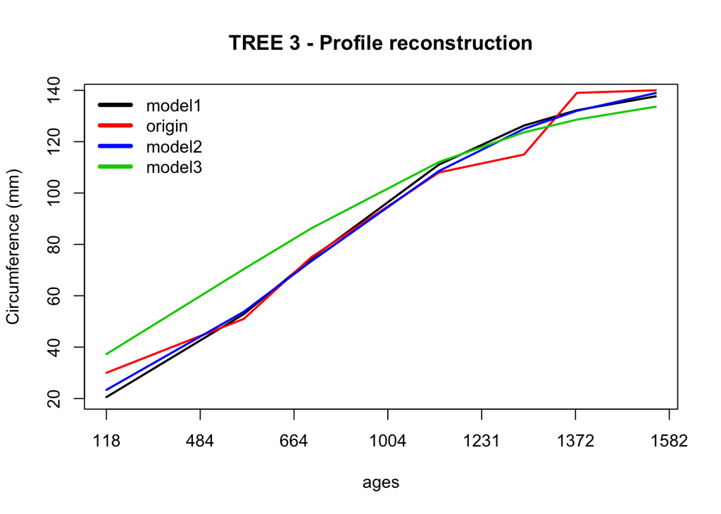

```r
# tree 3
matplot(ages, f1[3,], type = "l", lwd=2, ylab = "Circumference (mm)",xaxt='n')
points(ages, data$Y[3,], type = "l", col="red", lwd=2)
points(ages, f2[3,], type = "l", col="blue", lwd=2)
points(ages, f3[3,], type = "l", col="green3", lwd=2)
title(main="TREE 3 - Profile reconstruction")
legend(x="topleft", bty="n", legend = c("model1","origin","model2","model3"),
       col=c("black","red","blue","green3"), lwd = 4)
axis(1, at= seq(118,1800,250),labels = c(118, 484, 664, 1004, 1231, 1372, 1582))
```

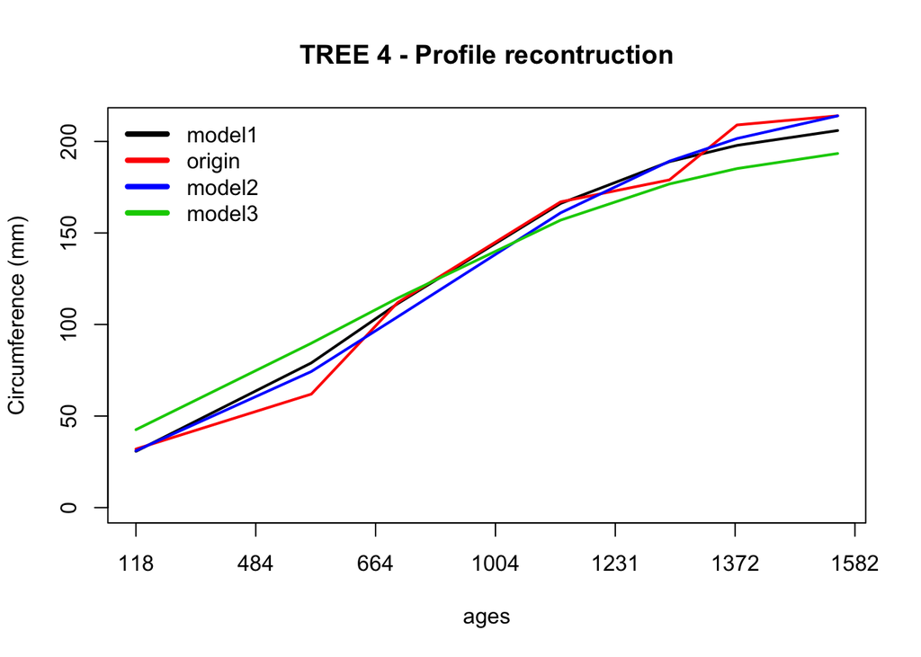

```r
# tree 4
matplot(ages, f1[4,], type = "l", lwd=2, ylab = "Circumference (mm)", ylim=c(0,210),xaxt='n')
points(ages, data$Y[4,], type = "l", col="red", lwd=2)
points(ages, f2[4,], type = "l", col="blue", lwd=2)
points(ages, f3[4,], type = "l", col="green3", lwd=2)
title(main="TREE 4 - Profile recontruction")
legend(x="topleft", bty="n", legend = c("model1","origin","model2","model3"),
       col=c("black","red","blue","green3"), lwd = 4)
axis(1, at= seq(118,1800,250),labels = c(118, 484, 664, 1004, 1231, 1372, 1582))
```

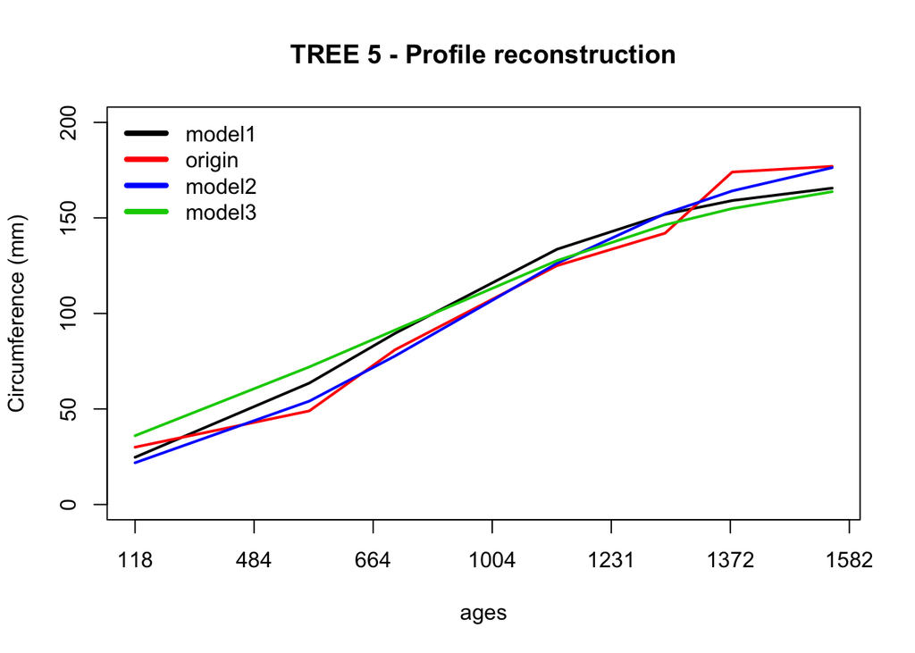

```r
# tree 5
matplot(ages, f1[5,], type = "l", lwd=2, ylab = "Circumference (mm)", ylim=c(0,200),xaxt='n')
points(ages, data$Y[5,], type = "l", col="red", lwd=2)
points(ages, f2[5,], type = "l", col="blue", lwd=2)
points(ages, f3[5,], type = "l", col="green3", lwd=2)
title(main="TREE 5 - Profile reconstruction")
legend(x="topleft", bty="n", legend = c("model1","origin","model2","model3"),
       col=c("black","red","blue","green3"), lwd = 4)
axis(1, at= seq(118,1800,250),labels = c(118, 484, 664, 1004, 1231, 1372, 1582))
```

### DIC evaluation

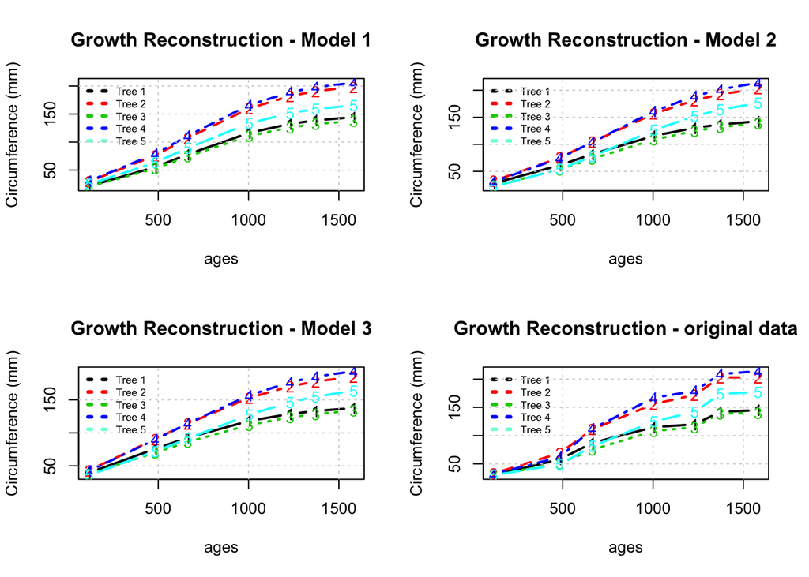

```r
par(mfrow=c(2,2))
matplot(ages, t(f1), type = "b", lwd=2, ylab = "Circumference (mm)")
legend('topleft',legend = c('Tree 1','Tree 2','Tree 3','Tree 4','Tree 5'),col=c('black','red','green3','blue','aquamarine'),lwd=3,bty = "n",lty=3,cex=0.65)
title(main="Growth Reconstruction - Model 1")
grid()

matplot(ages, t(f2), type = "b", lwd=2, ylab = "Circumference (mm)")
legend('topleft',legend = c('Tree 1','Tree 2','Tree 3','Tree 4','Tree 5'),col=c('black','red','green3','blue','aquamarine'),lwd=3,bty = "n",lty=3,cex=0.65)
title(main="Growth Reconstruction - Model 2")
grid()

matplot(ages, t(f3), type = "b", lwd=2, ylab = "Circumference (mm)")
legend('topleft',legend = c('Tree 1','Tree 2','Tree 3','Tree 4','Tree 5'),col=c('black','red','green3','blue','aquamarine'),lwd=3,bty = "n",lty=3,cex=0.65)
title(main="Growth Reconstruction - Model 3")
grid()

matplot(ages, t(data$Y), type = "b", lwd=2, ylab = "Circumference (mm)")
legend('topleft',legend = c('Tree 1','Tree 2','Tree 3','Tree 4','Tree 5'),col=c('black','red','green3','blue','aquamarine'),lwd=3,bty = "n",lty=3,cex=0.65)
title(main="Growth Reconstruction - original data")
grid()
```

Here we showed the DIC value for each parameter:

```
## [1] "Deviance information criterion --- Model 1 : 287.887635434834"
```

```
## [1] "Deviance information criterion --- Model 2 : 264.014838982605"
```

```
## [1] "Deviance information criterion --- Model 3 : 1597.24409965526"
```

We can state that the best model for these data is the second one, which has random effects on both $\beta_1$ and $\beta_2$.

Anyway, since the DIC is not a “stable” tool for model selection, we can check the reliability of our choice by counting how many times the model 2 DIC is actually the best one, over 100 simulation of *new* data from our known model (MODEL 2).

### Model selection check

```r
print(table(DICs))
```

```
## DICs
##  1  2  3
## 26 53 21
```

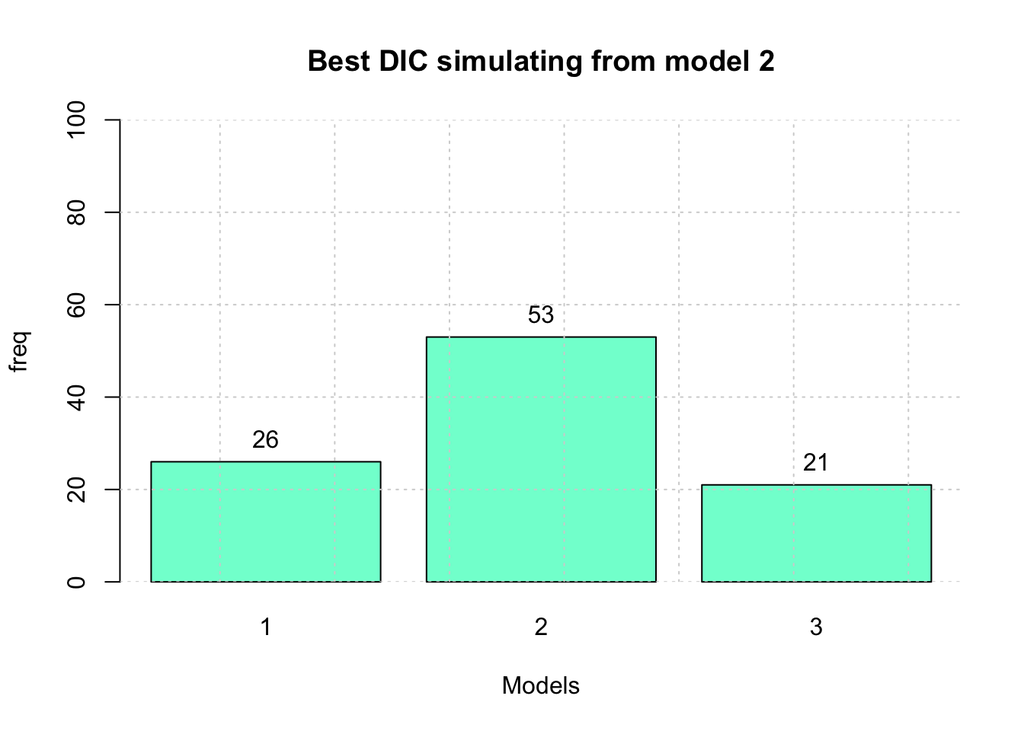

```r
plt = barplot(table(DICs), xlab = "Models", ylab = "freq",
              main = "Best DIC simulating from model 2", col = "aquamarine", ylim = c(0,100))
text(x = plt, y=table(DICs), label = table(DICs), pos = 3, cex = 1, col = "black")
grid()
```

## Evaluate Jags simulation

At this point we are able to evaluate the chains of each parameter obtained by JAGS simulations and visualize the approximated marginal posteriors.

```r
#here i show the effective size of each parameter of the model chosen
print(effectiveSize(orange2))
```

```
##  deviance       mu1       mu2   phi1[1]   phi1[2]   phi1[3]   phi1[4]
## 1568.8195 4341.9790 5049.2043  996.4530  595.7336  981.5881  542.6987
##   phi1[5]   phi2[1]   phi2[2]   phi2[3]   phi2[4]   phi2[5]      phi3
##  546.0443 1298.9969  788.9515 1205.5628  678.3679  694.9334  497.2249
##    sigma1    sigma2    sigmaC      tau1      tau2      tauC
## 3391.8455 5916.0898 2832.8061 4234.5204 3674.1825 3150.7089
```

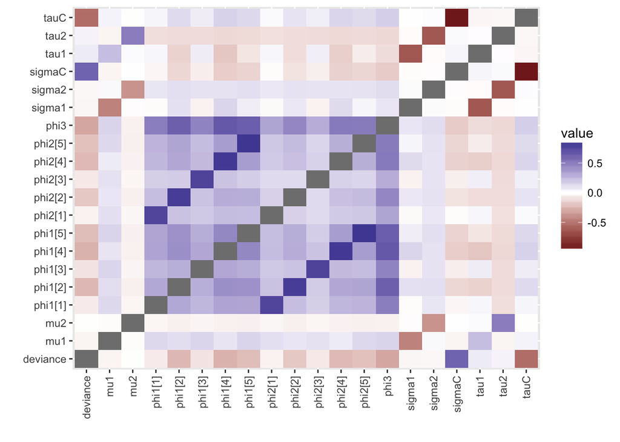

```r
#correlation plot
mod1.fit.gg <- ggs(as.mcmc(orange2))
ggs_crosscorrelation(mod1.fit.gg, absolute_scale = FALSE)
```

```r
# MODEL 2
mu1 = mcmc(orange2$BUGSoutput$sims.array[,1,c("mu1")])
mu2 = mcmc(orange2$BUGSoutput$sims.array[,1,c("mu2")])

sigma1 = mcmc(orange2$BUGSoutput$sims.array[,1,c("sigma1")])
sigma2 = mcmc(orange2$BUGSoutput$sims.array[,1,c("sigma2")])
sigmaC = mcmc(orange2$BUGSoutput$sims.array[,1,c("sigmaC")])

phi1$i1 = mcmc(orange2$BUGSoutput$sims.array[,1,c("phi1[1]")])
phi1$i2 = mcmc(orange2$BUGSoutput$sims.array[,1,c("phi1[2]")])
phi1$i3 = mcmc(orange2$BUGSoutput$sims.array[,1,c("phi1[3]")])
phi1$i4 = mcmc(orange2$BUGSoutput$sims.array[,1,c("phi1[4]")])
phi1$i5 = mcmc(orange2$BUGSoutput$sims.array[,1,c("phi1[5]")])

phi2$i1 = mcmc(orange2$BUGSoutput$sims.array[,1,c("phi2[1]")])
phi2$i2 = mcmc(orange2$BUGSoutput$sims.array[,1,c("phi2[2]")])
phi2$i3 = mcmc(orange2$BUGSoutput$sims.array[,1,c("phi2[3]")])
phi2$i4 = mcmc(orange2$BUGSoutput$sims.array[,1,c("phi2[4]")])
phi2$i5 = mcmc(orange2$BUGSoutput$sims.array[,1,c("phi2[5]")])
phi3 = mcmc(orange2$BUGSoutput$sims.array[,1,c("phi3")])

print(orange2$BUGSoutput$mean)
```

```
## $deviance
## [1] 243.4757
##
## $mu1
## [1] 176.7942
##
## $mu2
## [1] 86.83704
##
## $phi1
## [1] 150.1959 216.7658 147.7560 230.0745 192.6046
##
## $phi2
## [1] 603.8315 689.4537 666.5590 726.0753 791.8259
##
## $phi3
## [1] 327.1912
##
## $sigma1
## [1] 50.25498
##
## $sigma2
## [1] 729.9066
##
## $sigmaC
## [1] 7.945728
##
## $tau1
## [1] 0.0006786668
##
## $tau2
## [1] 3.036279e-06
##
## $tauC
## [1] 0.01691944
```

One way to see if our chain has converged is to see how well our chain is mixing, or moving around the parameter space.

If our chain is taking a long time to move around the parameter space, then it will take longer to converge.

We can see how well our chain is mixing through visual inspection.We need to do the inspections for every parameter.

Here we used:

- **Traceplots**
- **Autocorrelation plots**:
  - from which we would expect the $k_{th}$ lag autocorrelation to be smaller as k increases.

$$ρ_k = \frac{\sum_{i=1}^{n-k}(x_i − \bar x)(x_{i+k} − \bar x)}{\sum_{i=1}^{n}(x_i − \bar x)^2}$$

- We can also use **running mean plots** to check how well our chains are mixing:
  - A running mean plot is a plot of the iterations against the mean of the draws up to each iteration.

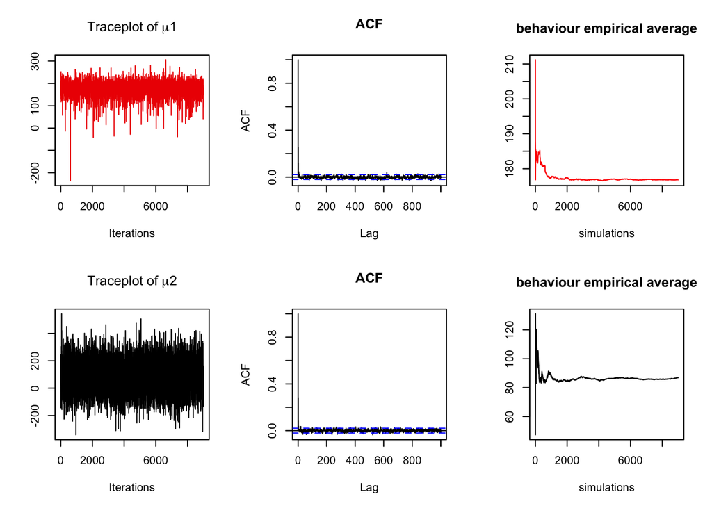

```r
par(mfrow=c(2,3))
traceplot(mu1, main = expression(paste("Traceplot of ",mu,"1")),col='red2')
acf(mu1, lag.max = 1000, main = "ACF")
plot(cumsum(mu1)/(1:length(mu1)), type="l", ylab="",
main="behaviour empirical average", xlab="simulations",col='red')



traceplot(mu2, main = expression(paste("Traceplot of ",mu,"2")))
acf(mu2, lag.max = 1000, main = "ACF")
plot(cumsum(mu2)/(1:length(mu2)), type="l", ylab="",
main="behaviour empirical average", xlab="simulations")
```

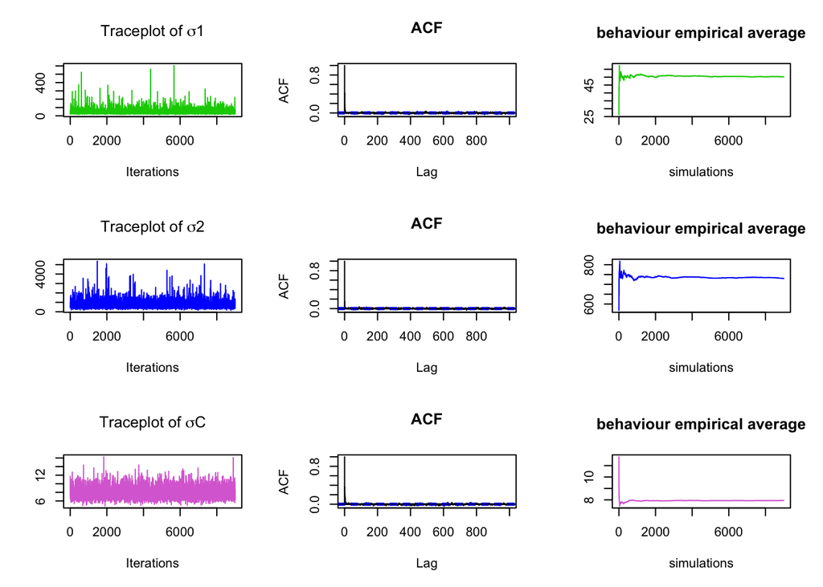

```r
par(mfrow=c(3,3))
traceplot(sigma1, main = expression(paste("Traceplot of ",sigma,"1")),col='green3')
acf(sigma1, lag.max = 1000, main = "ACF")
plot(cumsum(sigma1)/(1:length(sigma1)), type="l", ylab="",
main="behaviour empirical average", xlab="simulations",col='green3')


traceplot(sigma2, main = expression(paste("Traceplot of ",sigma,"2")),col='blue')
acf(sigma2, lag.max = 1000, main = "ACF")
plot(cumsum(sigma2)/(1:length(sigma2)), type="l", ylab="",
main="behaviour empirical average", xlab="simulations",col='blue')

traceplot(sigmaC, main = expression(paste("Traceplot of ",sigma,"C")),col='orchid')
acf(sigmaC, lag.max = 1000, main = "ACF")
plot(cumsum(sigmaC)/(1:length(sigmaC)), type="l", ylab="",
main="behaviour empirical average", xlab="simulations",col='orchid')
```

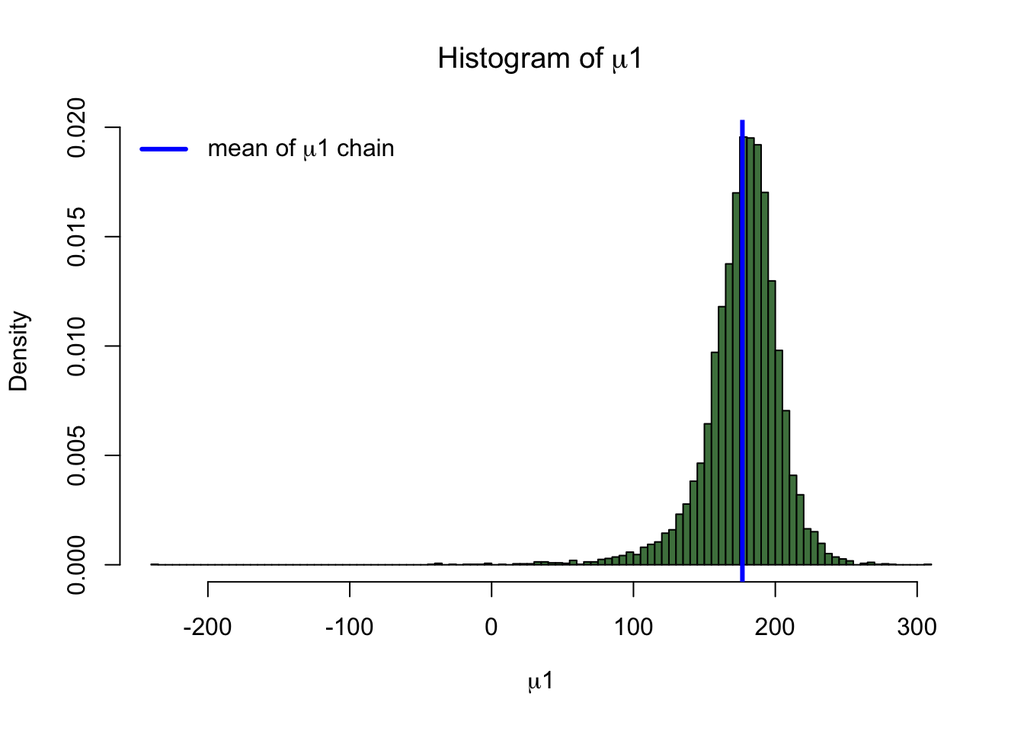

```r
par(mfrow=c(1,1))
hist(mu1,breaks = 100, main = expression(paste("Histogram of ",mu,"1")), freq = F,col = rgb(0.3,0.5,0.3),xlab = expression(paste(mu,"1")))
abline(v=orange2$BUGSoutput$mean$mu1, lwd=3, col="blue")
legend('topleft',legend = expression(paste("mean of ",mu,"1 chain")),col ='blue',lwd=3,bty='n')
```

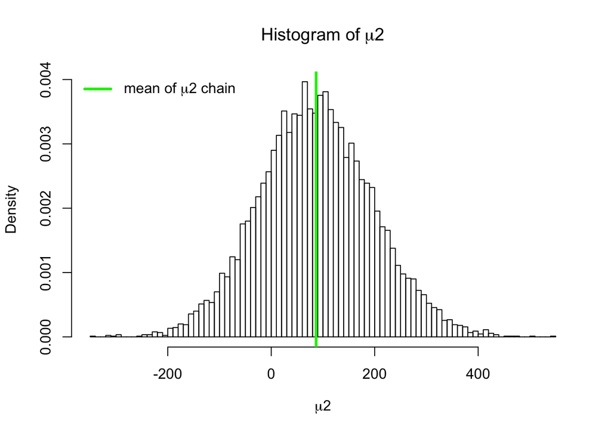

```r
hist(mu2,breaks = 100, main = expression(paste("Histogram of ",mu,"2")), freq = F,xlab = expression(paste(mu,"2")))
abline(v=orange2$BUGSoutput$mean$mu2, lwd=3, col="green2")
legend('topleft',legend = expression(paste("mean of ",mu,"2 chain")),col ='green2',lwd=3,bty='n')
```

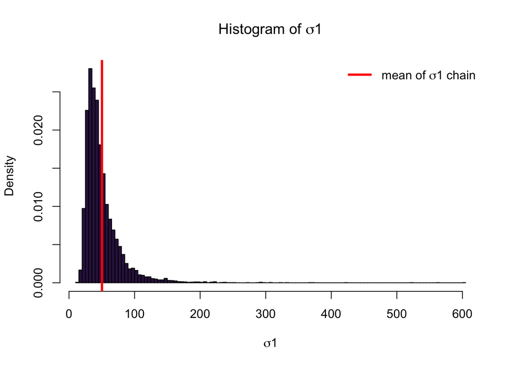

```r
hist(sigma1,breaks = 100, main = expression(paste("Histogram of ",sigma,"1")), freq = F,col = rgb(0.2,0.1,0.3),xlab = expression(paste(sigma,"1")))
abline(v=orange2$BUGSoutput$mean$sigma1, lwd=3, col="red")
legend('topright',legend = expression(paste("mean of ",sigma,"1 chain")),col ='red',lwd=3,bty='n')
```

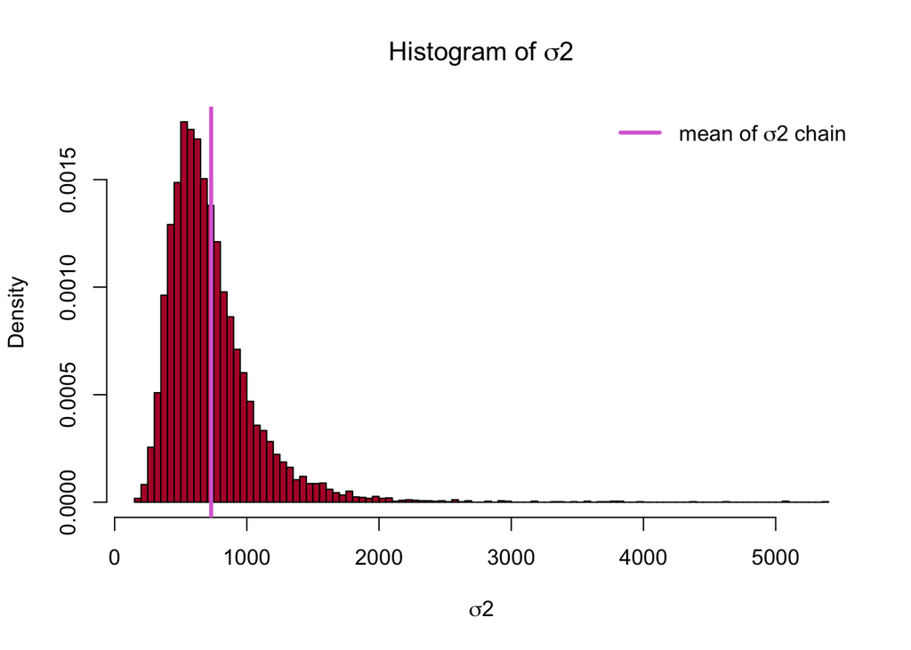

```r
hist(sigma2,breaks = 100, main = expression(paste("Histogram of ",sigma,"2")), freq = F,xlab = expression(paste(sigma,"2")),col = rgb(0.7,0.1,0.2))
abline(v=orange2$BUGSoutput$mean$sigma2, lwd=3, col="orchid")
legend('topright',legend = expression(paste("mean of ",sigma,"2 chain")),col ='orchid',lwd=3,bty='n')
```

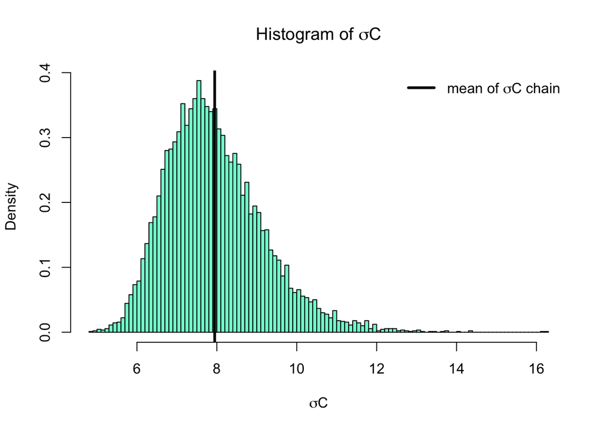

```r
hist(sigmaC,breaks = 100, main = expression(paste("Histogram of ",sigma,"C")), freq = F,xlab = expression(paste(sigma,"C")),col = 'aquamarine')
abline(v=orange2$BUGSoutput$mean$sigmaC, lwd=3, col="black")
legend('topright',legend = expression(paste("mean of ",sigma,"C chain")),col ='black',lwd=3,bty='n')
```

#### Another kind of of convergence diagnostic is the *Gelman and Rubin*, but it requires more than 1 chain.

Steps (for each parameter):

1. Run m ≥ 2 chains of length 2n from overdispersed starting values.
2. Discard the first n draws in each chain.
3. Calculate the within-chain and between-chain variance.
4. Calculate the estimated variance of the parameter as a weighted sum of the within-chain and between-chain variance.
5. Calculate the potential scale reduction factor.